# Examen de pruebas

Sergio Quijano Rey

sergioquijano@correo.ugr.es

# 1 Ejercicio 1

**Enunciado**: Establecer la semilla del generador de números aleatorios escribiendo set.seed(1). A continuación generar 50 valores desde una distribución Chi-cuadrado con n = 30 grados de libertad y almacenarlos en un vector y. Después generar 50 valores desde una distribución Normal con media µ = 30 y desviación típica σ = 5 y almacenarlos en un vector x. A partir de estos vectores se pide resolver la siguientes tareas:

Establecemos la semilla:

```r
set.seed(1)
```

Ahora, generamos los 50 valores desde una distribución Chi-cuadrado con 30 grados de libertad:

```r
# Parametros del muestreo
df <- 30
n <- 50

# Muestreo
y <- rchisq(n = n, df = df)
y
```

```
##  [1] 24.42529 40.01163 39.50007 32.24378 18.45781 32.83094 34.89548 33.55078
##  [9] 26.72086 23.23413 24.46174 26.76601 28.65881 22.60509 35.59144 33.69938
## [17] 36.42098 35.26244 29.57065 15.82831 32.96217 37.85842 23.97656 25.47283
## [25] 27.23269 28.22247 24.26468 19.46077 37.04826 25.82117 37.98257 35.10339
## [33] 27.76056 25.65421 33.39436 23.99179 18.31330 35.14829 28.15071 31.06226
## [41] 26.20207 31.65607 21.03676 30.93630 33.89951 27.70024 33.50115 27.98057
## [49] 28.91594 34.49077
```

Ahora generamos 50 valores desde una distribución normal de media 30 y desviación típica 5

```r
# Parametros del muestreo
n <- 50
mu <- 30
sigma <- 5

# Muestreo
x <- rnorm(n, mean = mu, sd = sigma)
x
```

```
##  [1] 30.14001 26.28363 30.94396 20.97521 37.32777 30.76627 40.86306 32.37755
##  [9] 26.45027 33.05363 25.32951 23.73183 31.45723 27.78354 30.00553 30.37171
## [17] 27.05240 27.15666 29.32411 35.89043 22.38217 32.96973 31.66475 35.31550
## [25] 28.47908 31.85009 31.33549 27.28740 36.03934 35.80201 33.50107 37.93417
## [33] 32.79243 23.61704 27.13367 23.87694 27.63300 26.89817 30.21058 25.44539
## [41] 30.79014 26.72708 38.83644 33.58354 34.55087 31.92093 38.41088 26.82132
## [49] 27.69178 37.16141
```

1. Calcular la media, la desviación típica y los tres cuartiles de y.

```r
y.mean <- mean(y)
y.mean
```

```
## [1] 29.39873
```

```r
y.sd <- sd(y)
y.sd
```

```
## [1] 5.872935
```

```r
y.q1 <- quantile(y, 0.25)
y.q2 <- quantile(y, 0.5)
y.q3 <- quantile(y, 0.75)

y.q1
```

```
##      25%
## 25.51818
```

```r
y.q2
```

```
##      50%
## 28.78737
```

```r
y.q3
```

```
##      75%
## 33.84948
```

2. Representar un histograma de los datos almacenados en y.

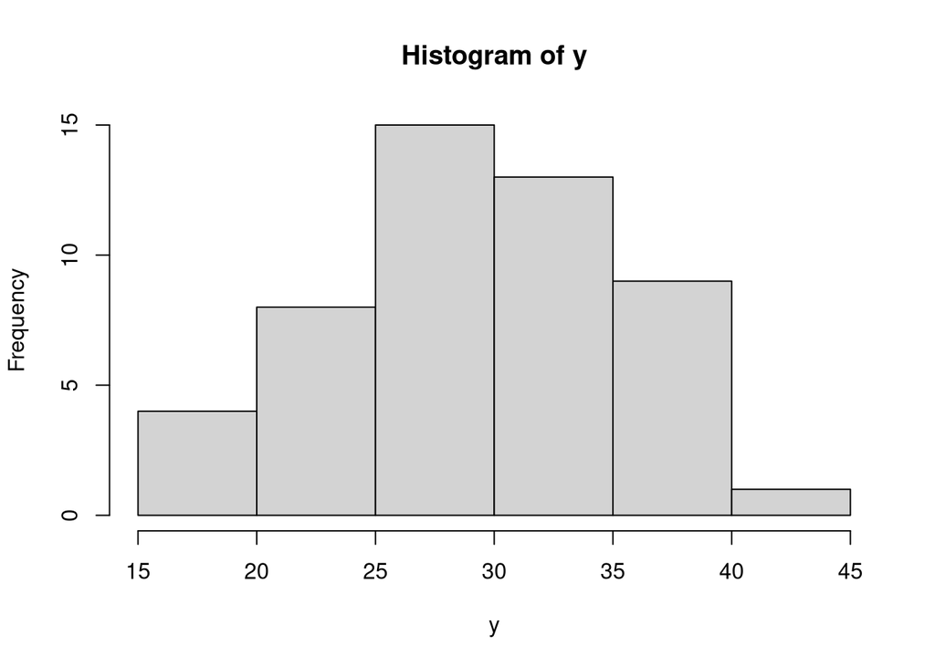

```r
hist(y)
```

3. Superponer al histograma anterior la curva de la densidad Normal con media y desviación típica la de los datos.

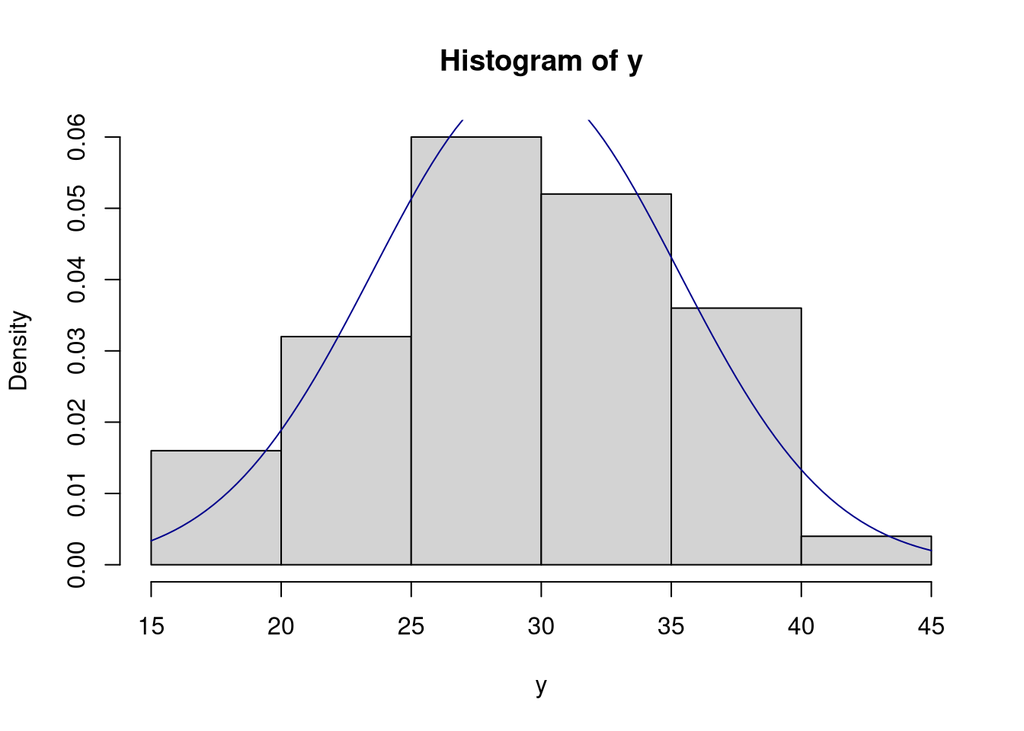

```r
# Vuelvo a poner el histograma del ej. anterior
# Hago freq = FALSE para usar frecuencia relativa y no absoluta
# Tambien me serviria `hist(y, prob = TRUE)`
hist(y, freq = FALSE)

# Superpongo la curva de la densidad normal
curve(dnorm(x, mean = y.mean, sd = y.sd), col = "darkblue", add = TRUE)
```

4. Representar un gráfico de probabilidad de los valores de y.

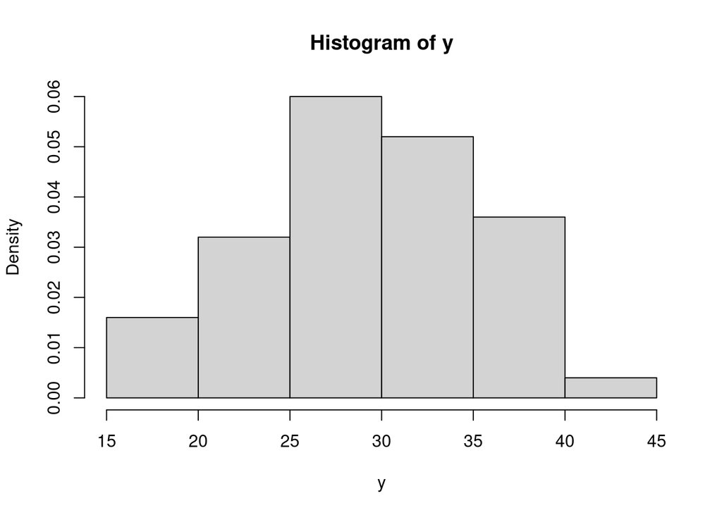

```r
# TODO -- no estoy nada seguro de esta
hist(y, prob = TRUE)
```

5. Representar un gráfico de cajas de los valores de y.

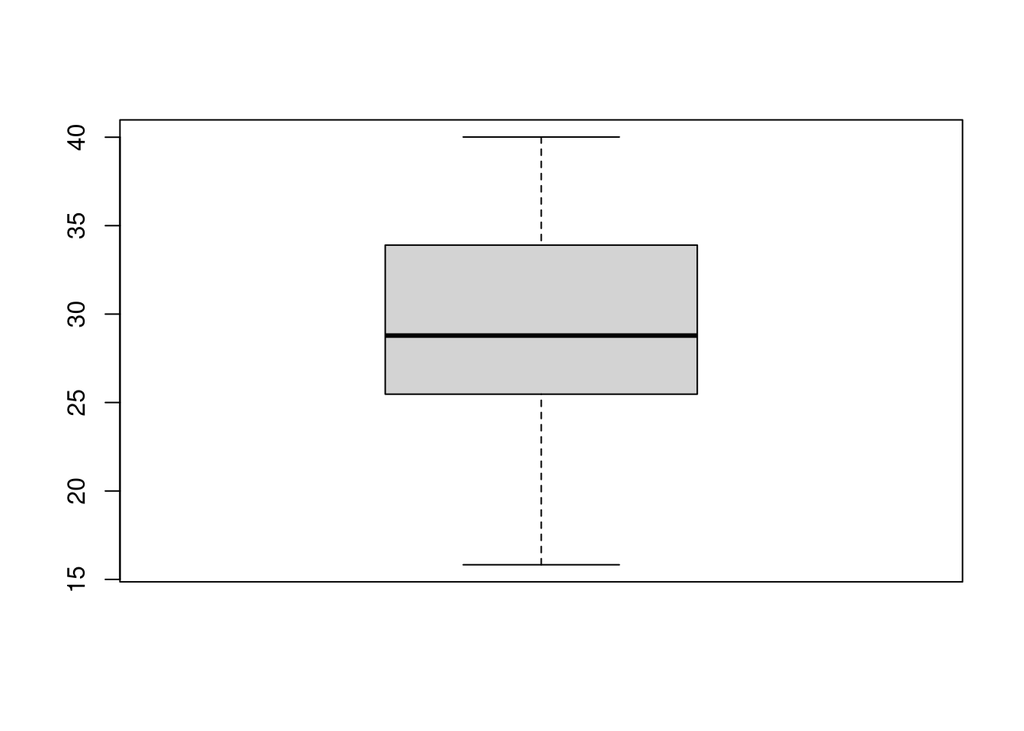

```r
boxplot(y)
```

6. Representar un gráfico de cajas múltiples (2 cajas) que permita comparar la distribución de x e y.

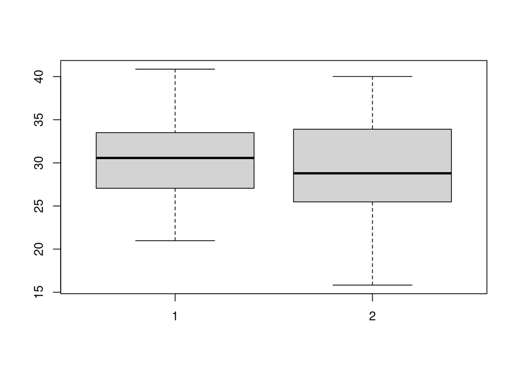

```r
boxplot(x, y)
```

7. Representar un diagrama de dispersión de los valores de x (en el eje horizontal) frente a los de y (en el eje vertical).

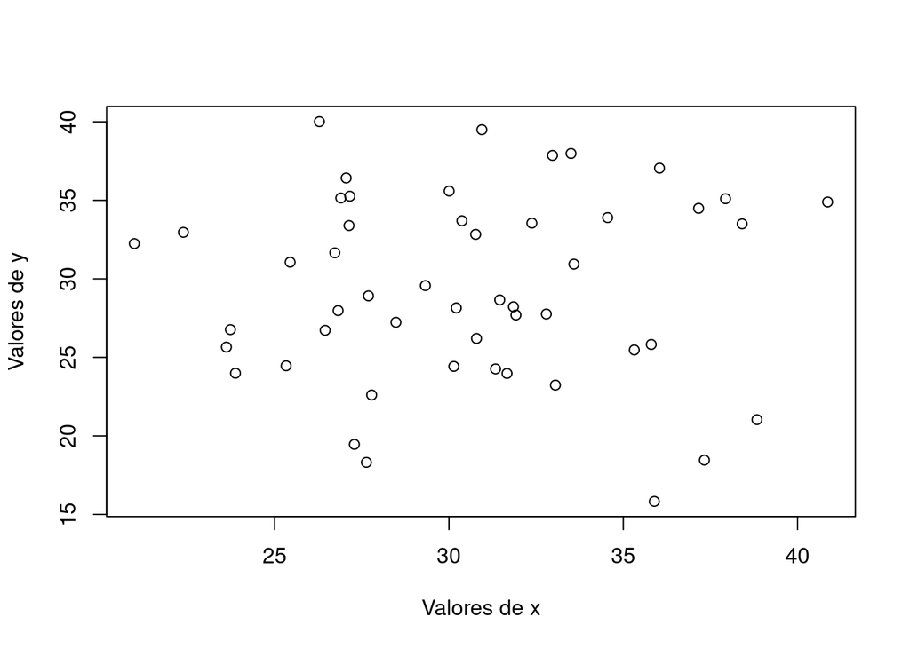

```r
plot(x, y, ylab = "Valores de y", xlab = "Valores de x")
```

8. Ajustar un modelo de regresión lineal
   $$y_i = \beta_0 + \beta_1 x_i + \epsilon_i ; i \in
   \Delta_{50}$$
   con los datos almacenados en x e y. Representar el modelo ajustado (la recta de regresión) sobre el diagrama de dispersión anterior.

Empiezo realizando el ajuste:

```r
# Pongo todo en un dataframe para que sea mas sencillo realizar el ajuste
df <- data.frame(x = x, y = y)

# Aplico el ajuste usando el data frame anterior
mod <- lm(formula = y ~ x, data = df)
mod
```

```
##
## Call:
## lm(formula = y ~ x, data = df)
##
## Coefficients:
## (Intercept)            x
##    29.07146      0.01072
```

Ahora superpongo el gráfico anterior sobre el *scatter plot*:

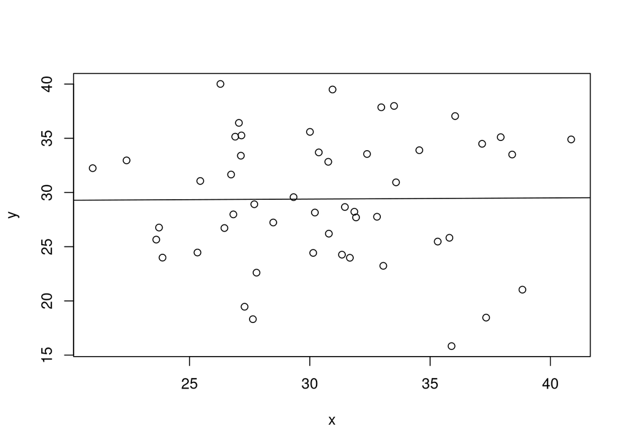

```r
# Empiezo haciendo el scatter plot
plot(x, y)

# Ahora añado la linea que me da el ajuste realizado
abline(mod)
```

# 2 Ejercicio 2

**Enunciado**: En 1651, el Caballero de Méré le planteó a Pascal una pregunta relacionada con las apuestas en juegos de azar: ¿sería adecuado apostar a que en cuatro lanzamientos de un dado se obtendrá al menos un seis? Este problema generó una fructífera correspondencia entre Pascal y Fermat que se contribuyó al nacimiento del Cálculo de Probabilidades. Se pide:

1. Escribir una función que simule el lanzamiento de n dados. La función tendrá un único argumento, el número de lanzamientos n, y tomará el valor 4 por defecto. La función devolverá como posibles valores TRUE, si se obtiene al menos un 6 y FALSE en caso contrario

```r
# Simula el lanzamiento de `n` dados. Devuelve TRUE si en los `n` lanzamientos
# sale al menos un 6, y devuelve FALSE en otro caso
lanzamiento_dados <- function(n = 4) {
    # Simulamos los lanzamientos de n monedas de seis caras
    monedas <- 1:6
    lanzamientos <- sample(x = monedas, size = n, replace = TRUE)

    # Contamos el numero de lanzamientos en los que sale un 6
    lanzamientos_buenos <- length(which(lanzamientos == 6))

    # Devolvemos si al menos ha habido un lanzamiento bueno
    return(lanzamientos_buenos > 0)
}

lanzamiento_dados()
```

```
## [1] FALSE
```

```r
# Establecemos los parametros de la simulacion
simulaciones <- 1000
n <- 4

# Realizamos las simulaciones
resultados <- vector()
for(i in 1:simulaciones){
    resultados[i] <- lanzamiento_dados(n)
}

# Calculamos las simulaciones con exito y sin exito
exito <- sum(resultados)
fracaso <- sum(!resultados)

# Calculamos ahora la probabilidad
prob <- exito / (exito + fracaso)
prob
```

```
## [1] 0.522
```

```r
# Comparamos ese valor con el real
prob_real <- 1 - (5/6)^n
prob_real
```

```
## [1] 0.5177469
```

```r
# Realizamos una comparacion mas numerica
abs_err <- abs(prob - prob_real)
abs_err
```

```
## [1] 0.004253086
```

```r
perc_err <- abs_err / prob_real * 100
perc_err
```

```
## [1] 0.8214605
```

# 3 Ejercicio 3